# Contact Tracing Database Report

Hasti Gheibi Dehnashi, Audrey Jo, Thinh Lam

10/11/2020

The objective of this project is to design a database to support digital tools that will augment traditional contact tracing. Contact tracing is a necessary step for preventing COVID-19 until a coronavirus vaccine is developed. Traditional contact tracing is cumbersome work that relies heavily on the health service professional. Digital tools that support self-reporting and automated follow-ups can improve timeliness and efficiency in the contact tracing process. We have created a database that can support contact tracing and be used by epidemiologists studying the spread of the disease. In this report you will find the following documents describing the contact tracing database:

# Table of Contents

**UML Class Diagram**

**ER Diagram**

**Relational Schema**

**Database Generation**

**Use Cases**

# UML Class Diagram

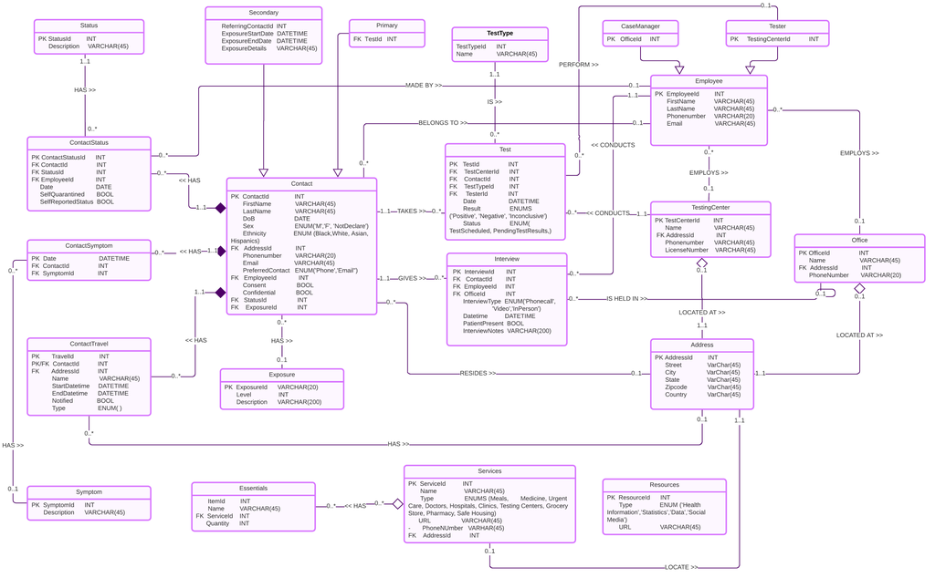

Figure 1. UML Conceptual Class Diagram of the contact tracing database

View the UML Class Diagram PDF, or view it in [LucidCharts](https://app.lucidchart.com/documents/view/531437ab-31e5-4e76-a52e-96927ff77e32)

# Entity Relationship (ER) Diagram

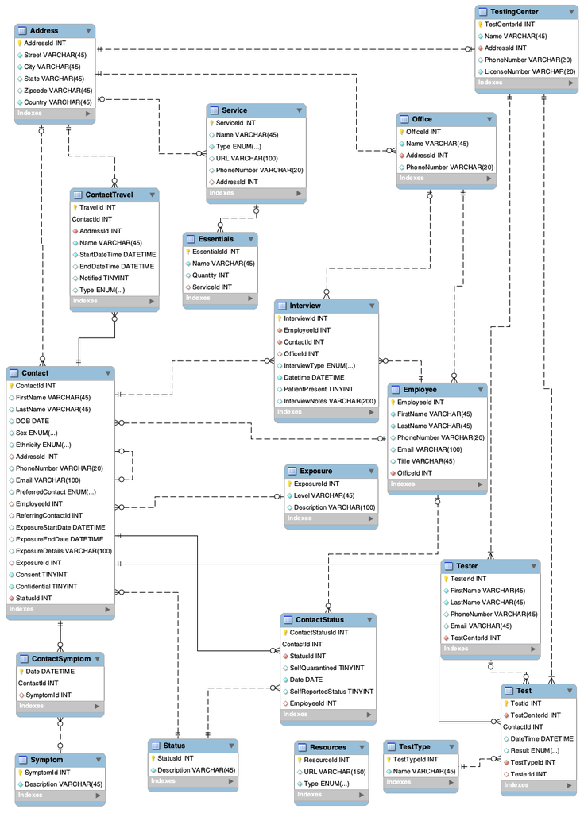

Figure 2. ER Diagram of the contact tracing database

# Relational Schema

View the relational schema [Google Doc](https://docs.google.com/document/d/1NMjmoAV1o2M1eEd9LXyGxg1LmjMiOR28-jAlqOzXcZE/edit?usp=sharing) or PDF

By definition, a relational Schema is in BCNF if and only if it is in 3NF and every non-trivial Functional Dependency has a candidate key as its determinant. We designed our database such that each candidate key is used as a determinant.

Set of candidate keys = {ContactId, AddessId,EmployeeId, StatusId, ExposureId, InterviewId, OfficeId, TestCenterId, ResourceId, ServiceId, ItemId, SymptomId, TravelId, ContactSymptomId, ContactStatusId, TestId }

TravelId -> ContactId, AddressId, Name, StartDateTime, EndDateTime, Notified, Type

ContactSymptomId -> Date, ContactId SymptomId

SymptomId -> Symptom

ContactStatusId-> ContactId, StatusId, EmployeeId, Date, SelfQuarantined

StatusId -> Description

ExposureId -> Level, Description

EmployeeId -> FirstName, LastName, PhoneNumber, Email.

OfficeId -> Name, AddressId, PhoneNumber

TestCenterId -> Name, AddressId, PhoneNumber, LicenceNumber

TestId -> TestCenterId, TesterId, Date, Result

InterviewId -> EmployeeId, ContactId, OfficeId, InterviewType, DateTime, PatientPresent, InterviewNotes

AddressId -> Street, City, State, Zipcode, Country

ServiceId -> Name, Type, URL, PhoneNumber, AddressId

ItemId -> Name, ServiceId, Quantity

ResourceId ->Type , URL

# Database Generation

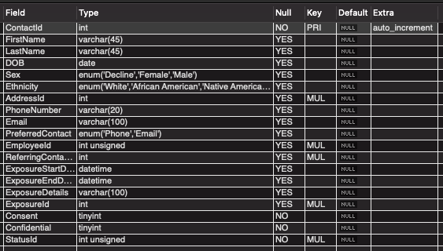

Figure 3a. Contact table

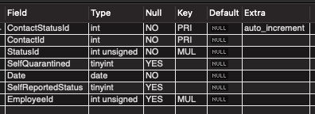

Figure 3b. ContactStatus table

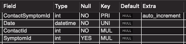

Figure 3c. ContactSymptom table

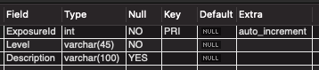

Figure 3d. Exposure table

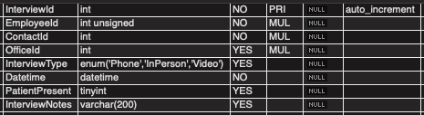

Figure 3e. Interview table

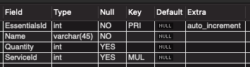

Figure 3f. Essentials table

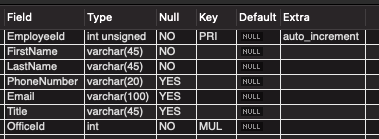

Figure 3g. Employee Table

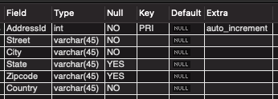

Figure 3h. Address Table

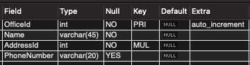

Figure 3i. Office Table

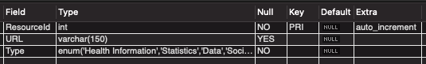

Figure 3j. Resources table

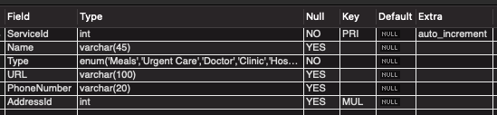

Figure 3k. Service table

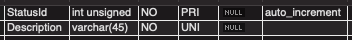

Figure 3l. Status table

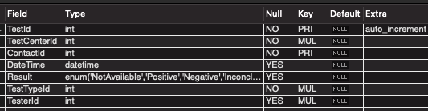

Figure 3n. Test table

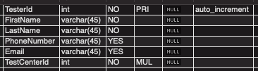

Figure 3o. Tester table

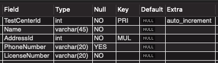

Figure 3p. TestingCenter table

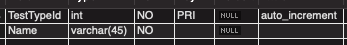

Figure 3q. TestTypes table

# Use Cases

We selected 5 use cases to showcase how the database can be utilized for automated contact tracing, they are discussed below.

1. Enable automated notification to contacts who opt-in to being notified
2. Allow notifications to be tailored to the likelihood of exposure based on the risk level
3. Enable automatic prioritization of self reported symptom for immediate contact notification to suggest testing, and health department notification
4. Find the contacts which have taken tests and determine the type of test
5. Send daily automated monitoring checks to Self-Quarantined Patient

The queries are available for viewing in this .sql file